# Preliminary Look at Schools over Time

Gregor Thomas

2023-12-30

> The object of inquiry here is the school - how has each school’s number of reported practices changed?

We’ll begin by including schools that participated in 2, 3, and 4 surveys, and looking at how many practices they selected each year in total. (The blue line shows the average, and the points for each school are conected by light gray lines.)

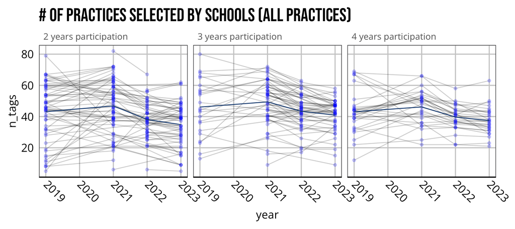

The above reflects the number of practices available to select, it is effected by what practices schools indicate, but also the number of choices they were given each year. Below, we recreate the same graph but limit it to practices that were included in all 4 surveys. Comparing the two, we see above decreases in the averages, but this is mostly due to culling of tags–below we can see that the averages increase over time.

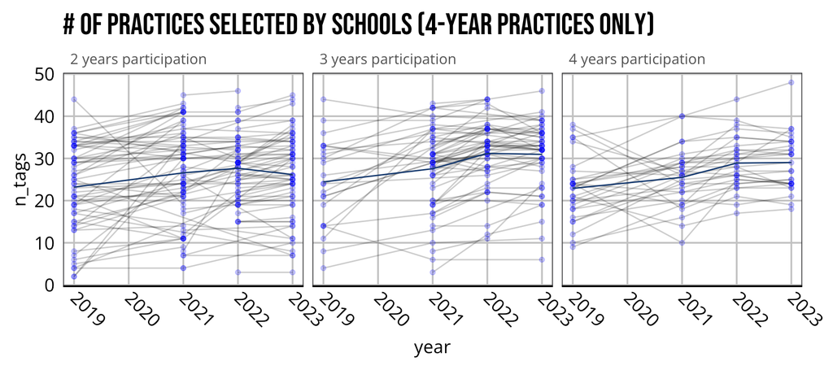

The table below shows the blue-line averages of the above graph (with 4-year practices). There we can see that while the average number of selected practices by about 6-7 practices over the entire 2019-2023 period (focusing mostly on the schools responding in 3 or 4 years). It seems safe to say that repeat Canopy schools typically add 1-2 practices per year.

| year | n_years | avg_tags |
| --- | --- | --- |
| 2019 | 2 | 23.1964285714286 |
| 2021 | 2 | 26.5822784810127 |
| 2022 | 2 | 27.6666666666667 |
| 2023 | 2 | 26.1694915254237 |
| 2019 | 3 | 24.4347826086957 |
| 2021 | 3 | 27.5576923076923 |
| 2022 | 3 | 31.1914893617021 |
| 2023 | 3 | 30.9591836734694 |
| 2019 | 4 | 22.8965517241379 |
| 2021 | 4 | 25.5172413793103 |

[output cut: 2 more lines]

Which schools are adding and dropping practices? The table below shows, for each school responding to multiple surveys, how many practices they added, dropped, and waffled on (both added and dropped). While the average may be 6 or 7 practices added overall, plenty of schools have added 20+ practices.

I recommend digging deeper into the waffling, especially the few schools that have a lot of waffling. If a school indicates a practice was dropped and then re-added, there are possibilities of data compilation error, survey response error, or a COVID blip, and we may not want to read too much into any of those.

I’d also be interested in the schools that appear to have made drastic changes–if those changes can be corroborated and explained with some interviews or even just another survey response, it may be worth targeting them for some outreach.

| school_id | school_name | n_years | added | dropped | waffled | net_adds |
| --- | --- | --- | --- | --- | --- | --- |
| 183 | Shawnee High School | 2 | 32 | 0 | 0 | 32 |
| 130 | Minnesota New Country School | 2 | 29 | 1 | 0 | 28 |
| 69 | EPIC Elementary | 3 | 29 | 3 | 0 | 26 |
| 140 | Noble High School | 3 | 29 | 4 | 3 | 25 |
| 477 | Paramount Brookside | 2 | 21 | 0 | 0 | 21 |
| 49 | Crosstown High | 2 | 21 | 1 | 0 | 20 |
| 229 | Winterboro High School | 2 | 20 | 0 | 0 | 20 |
| 268 | Environmental Charter Middle School | 2 | 20 | 1 | 0 | 19 |
| 198 | Stuttgart Junior High School | 2 | 19 | 0 | 0 | 19 |
| 150 | One Stone | 4 | 21 | 3 | 3 | 18 |

[output cut: 192 more lines]

## Focus on the Wafflers

Purdue Polytechnic and Juab HS waffled a lot. Here’s the raw data, including all practices that they selected in at least 1 year.

| school_id | school_name | tag | 2019 | 2021 | 2022 | 2023 | added | dropped | waffled |
| --- | --- | --- | --- | --- | --- | --- | --- | --- | --- |
| 105 | Juab High School | practices_competency_education | 1 | 0 | 1 | 1 | True | True | True |
| 105 | Juab High School | practices_station_rotation | 1 | 0 | 1 | 0 | True | True | True |
| 105 | Juab High School | practices_flipped_classroom | 0 | 1 | 1 | 0 | True | True | True |
| 105 | Juab High School | practices_flex | 1 | 0 | 1 | 1 | True | True | True |
| 105 | Juab High School | practices_enriched_virtual | 0 | 1 | 1 | 0 | True | True | True |
| 105 | Juab High School | practices_opportunities_mastery | 1 | 0 | 0 | 1 | True | True | True |
| 105 | Juab High School | practices_grading_mastery | 1 | 0 | 1 | 1 | True | True | True |
| 105 | Juab High School | practices_competency_framework | 1 | 0 | 1 | 1 | True | True | True |
| 105 | Juab High School | practices_student_goals | 1 | 0 | 1 | 1 | True | True | True |
| 105 | Juab High School | practices_student_pace | 1 | 0 | 0 | 1 | True | True | True |

[output cut: 67 more lines]

Here’s a summary of the patterns, where 1 indicates selected and 0 indicates not selected in each survey, respectively. E.g., “1,0,1,1” means the practice was selected in 2019, not selected in 2021, and then selected again in 2022 and 2023. `n` is the number of practices for which this pattern was observed. We can see that Juab HS has 11 tags with the `1,0,1,1` pattern, meaning there are 11 practices that Juab indicated in all survey years *except* 2021.

| school_name | binary_summary | n |
| --- | --- | --- |
| Juab High School | 0,0,0,1 | 2 |
| Juab High School | 0,0,1,1 | 2 |
| Juab High School | 0,1,1,0 | 3 |
| Juab High School | 0,1,1,1 | 7 |
| Juab High School | 1,0,0,0 | 9 |
| Juab High School | 1,0,0,1 | 2 |
| Juab High School | 1,0,1,0 | 2 |
| Juab High School | 1,0,1,1 | 11 |
| Purdue Polytechnic High Schools | 0,1,0,0 | 1 |
| Purdue Polytechnic High Schools | 0,1,1,0 | 2 |

[output cut: 4 more lines]

## Practices added and dropped

The next obvious question is which practices are schools adding and dropping? Again, we look at the tags present on all 4 surveys and see how many multiply-responding schools added or dropped them. The “waffled” column counts schools that both added and dropped the practice

|  | var | added | dropped | waffled | net_adds |
| --- | --- | --- | --- | --- | --- |
| 1 | practices_sel_curriculum | 53 | 6 | 2 | 47 |
| 2 | practices_culturally_responsive | 49 | 2 | 0 | 47 |
| 3 | practices_blended_learning | 61 | 20 | 9 | 41 |
| 4 | practices_student_projects | 49 | 11 | 3 | 38 |
| 5 | practices_udl | 47 | 9 | 2 | 38 |
| 6 | practices_assessments_career | 46 | 8 | 2 | 38 |
| 7 | practices_community_supports | 48 | 11 | 2 | 37 |
| 8 | practices_extended_learning | 43 | 6 | 1 | 37 |
| 9 | practices_sel_integrated | 41 | 6 | 0 | 35 |
| 10 | practices_restorative | 39 | 5 | 1 | 34 |

[output cut: 39 more lines]

I am surprised by how many drops there are - 10 practices are dropped by 20 or more schools, and the 3 most dropped practices are dropped by 40+ schools. Those 3 are also the highest on the “waffle” count and should be investigated more deeply before we jump to conclusions. I can imagine a COVID-effect or an error in combining the data.

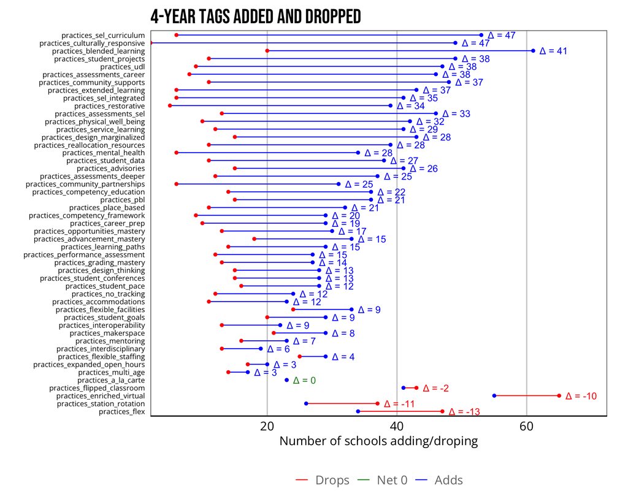

## Broadening: Practices in 2+ years

Repeating the above analyses, but expanding the scope to include practices on the survey in 2023 and at least 1 other year.

| school_id | school_name | n_years | added | dropped | waffled | net_adds |
| --- | --- | --- | --- | --- | --- | --- |
| 183 | Shawnee High School | 2 | 32 | 0 | 0 | 32 |
| 130 | Minnesota New Country School | 2 | 29 | 1 | 0 | 28 |
| 477 | Paramount Brookside | 2 | 27 | 0 | 0 | 27 |
| 69 | EPIC Elementary | 3 | 29 | 3 | 0 | 26 |
| 140 | Noble High School | 3 | 29 | 5 | 3 | 24 |
| 268 | Environmental Charter Middle School | 2 | 23 | 1 | 0 | 22 |
| 150 | One Stone | 4 | 23 | 3 | 3 | 20 |
| 49 | Crosstown High | 2 | 21 | 1 | 0 | 20 |
| 229 | Winterboro High School | 2 | 20 | 0 | 0 | 20 |
| 198 | Stuttgart Junior High School | 2 | 19 | 0 | 0 | 19 |

[output cut: 196 more lines]

Note that a practice included in only two years couldn’t possibly be “waffled”, so there will be relatively fewer waffles for these 2-year tags, and even 3-year tags have less opportunity to waffle.

|  | var | added | dropped | waffled | net_adds |
| --- | --- | --- | --- | --- | --- |
| 1 | practices_sel_curriculum | 53 | 6 | 2 | 47 |
| 2 | practices_culturally_responsive | 49 | 2 | 0 | 47 |
| 3 | practices_blended_learning | 61 | 20 | 9 | 41 |
| 4 | practices_student_projects | 49 | 11 | 3 | 38 |
| 5 | practices_udl | 47 | 9 | 2 | 38 |
| 6 | practices_assessments_career | 46 | 8 | 2 | 38 |
| 7 | practices_community_supports | 48 | 11 | 2 | 37 |
| 8 | practices_extended_learning | 43 | 6 | 1 | 37 |
| 9 | practices_sel_integrated | 41 | 6 | 0 | 35 |
| 10 | practices_restorative | 39 | 5 | 1 | 34 |

[output cut: 50 more lines]

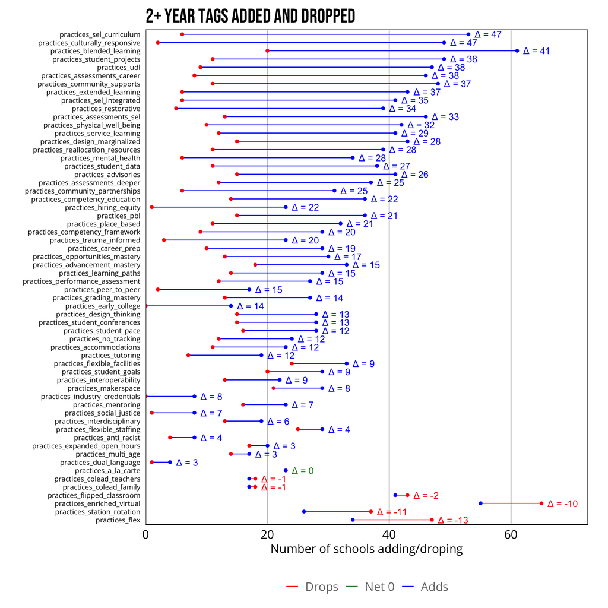

# Little bit of modeling

Here we’ll build a model for how volatile/dynamic school’s tagging practices are.

We’ll look **within schools**. For all schools with multiple responses, we’ll make a data point out of each consecutive survey response, and for the tags that were used in both of those response years, we will look at the **number of practices changed** (number added plus number dropped). We will then model count of practice changes using school demography and ecology as predictors.

The time periods are important too, and we know that the pandemic had a large effect on many practices. To try to capture the relevant time details without overcomplicating the model, we will classify each time transition into one of four cases:

For now, we will not put the number of years in the transition as a numeric variable, as that will be mostly dependent on the transition types, though with more years of data we may want to include that (and perhaps keep things focused post-pandemic).

|  | n_missing |
| --- | --- |
| title_i_schoolwide | 235 |
| total_enroll | 32 |
| enroll_scaled | 32 |
| stu_poc_pct | 14 |
| grades_elementary | 14 |
| locale | 13 |
| grades_middle | 12 |
| grades_high | 11 |
| school_id | 0 |
| year | 0 |

[output cut: 3 more lines]

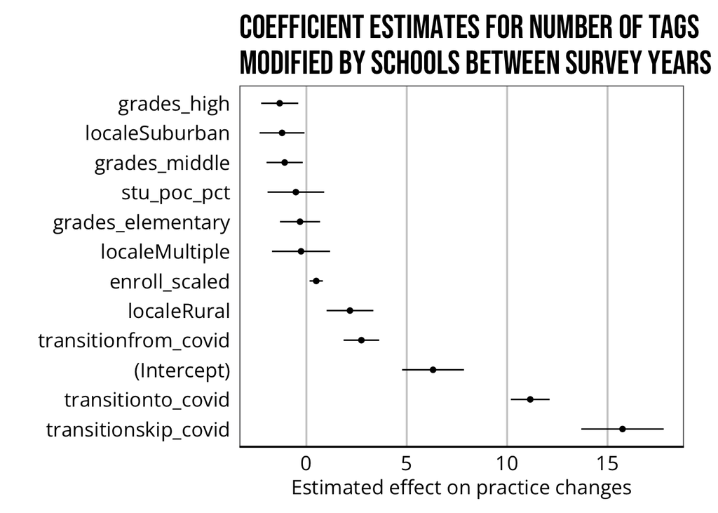